# Flight Delays

## Goal

Which airport near New York City has the shortest departure delays on Saturday?

## Motivation

Airline passengers have choices when they choose to fly in to or out of New York City. Three major airports serve the area:

- **JFK** - John F Kennedy International Airport
- **LGA** - LaGuardia Airport
- **EWR** - Newark Liberty International Airport

How should passengers choose which airport to depart from? This study compares the airports on an obvious criteria: *departure delays*, the amount of time that passes between when a plane is scheduled to depart and when it actually departs. The amount of delay varies by ariport and fluctuates throughout the year, as seen in the graph below.

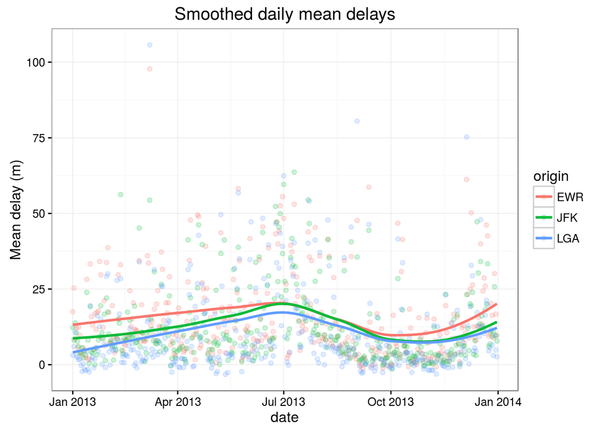

Since passengers can normally plan which day of the week they travel on, we will condition our analysis on a single day of the week: Saturday.

## Data

We will examine all flights that originated from a New York City airport in 2013. The data is provided by the Bureau of Transportation Statistics (BTS) and is available for download from http://www.transtats.bts.gov/DL_SelectFields.asp?Table_ID=236. We access the data through the `nycflights13` R package (Wickham 2014).

## Conclusion

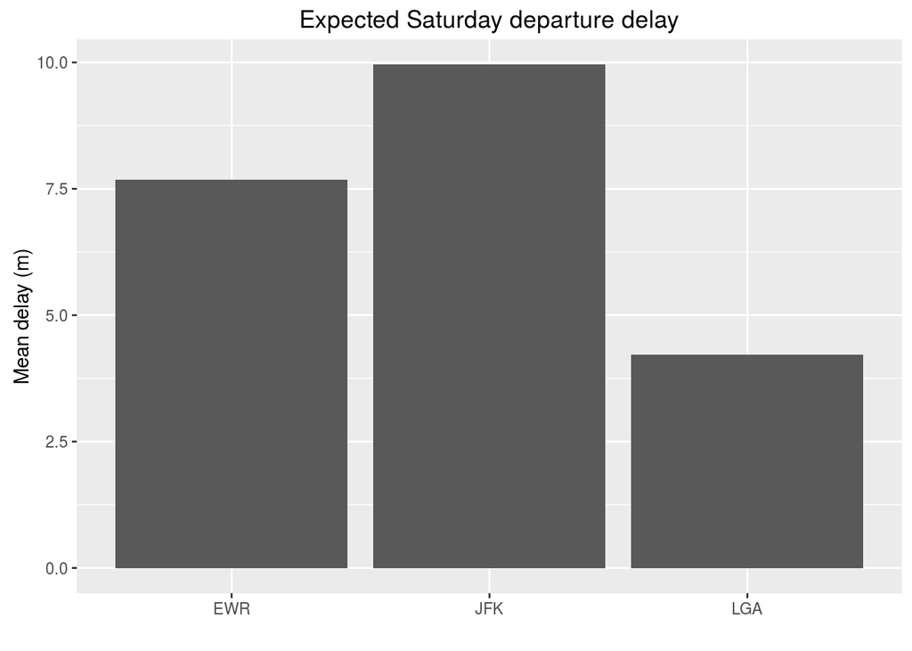

As the plot above shows, LaGuardia Airport had the shortest mean departure delay on Saturday, with a mean delay of 4.23 minutes.

The complete results are in the table below.

| origin | mean_delay |
| --- | --- |
| EWR | 7.680089 |
| JFK | 9.957610 |
| LGA | 4.226548 |

## References

Wickham, Hadley. 2014. *Nycflights13: Data About Flights Departing NYC in 2013.* https://CRAN.R-project.org/package=nycflights13.